# Normalizacion de datos de RNA-seq y Expresion diferencial

#### Normalizo por FPKM o RFPKM (Fragments Per Kilobase Million):

```r
# RealMatrix_paired <- procesamiento para tomar nada mas las reads de uno de los pares
# RealMatrix_paired <- apply(RealMatrix_paired, 2, function(x) x/TrscLength)
# RealMatrix_paired <- RealMatrix_paired*`1K`
# RealMatrix_paired <- apply(RealMatrix_paired, 1, function(x) x/SeqDepth)
# RealMatrix_paired <- RealMatrix_paired*`1M` %>%
#   round(4)
```

- FPKM si considera la longuitud del transcripto.
- FPKM es aceptable cuando el protocolo de secuenciacion genera un numero de reads proporcionales al tamano del transcripto. Dos transcriptos se expresan igual, pero como uno mide 1000pb y el otro 100pb, entonces el primero tiene 10 veces mas reads que el segundo.
- FPKM se usa cuando la secuenciacion e pair-end, porque si los fragmentos estan pareados se cuentan como 1.

Sin embargo, tanto RPKM como FPKM son insconsistentes entre muestras ya que el numero de reads totales (SeqDepth) no es proporcional al numero de cDNA totales por el tema de que el numero de reads depende de la la longuitud de los transcriptos.  
Aca hay unos links para entender mejor de esto: - http://luisvalesilva.com/datasimple/rna-seq_units.html  
- https://www.rna-seqblog.com/rpkm-fpkm-and-tpm-clearly-explained/  
Entonces lo que se usa para manejar esto son los TPMs

#### Transformo los counts a TPMs (Transcripts Per Kilobase Million):

```r
RealMatrix_tpm <- RealMatrix[rownames(RealMatrix) %in% TrscNames_final,]
# Expresion cada transcripto relativa a su longuitud
RealMatrix_tpm <- apply(RealMatrix_tpm, 2, function(x) x/TrscLength)
RealMatrix_tpm <- RealMatrix_tpm*`1K`
# Sumo todos los valores de expresion relativa de una muestra
RelativesSum <- apply(RealMatrix_tpm, 2, sum)
# Expresion relativa a la longuitud de cada transcripto, relativa a la expresion relativa total de la muesta
RealMatrix_tpm <- apply(RealMatrix_tpm, 1, function(x) x/RelativesSum) %>% t()
RealMatrix_tpm <- RealMatrix_tpm*`1M` %>%
  round(4)
```

Como se interpreta?  
Como el numero de “cDNAs” (o transcriptos) asignados a un determinado transcripto/gen de un total de 1M de transcriptos.  
De las normalizaciones que tienen en cuenta la longuitud del transcripto, muchas, en vez de usar la longuitud del transcripto como tal (TrscLength) usan lo que se llama el “Effective Length” que vendria a ser el numero de posiciones en las cuales un read puede empezar a lo largo del transcripto (sin pasarse del final del transcripto). Pero las diferencias entre usar el TrscLength o el Effevtive Size no son muchas. Mas info aca: https://www.biostars.org/p/253789/

##### Busco ahora los genes que tengan varianza distinta de cero a lo largo de las mustras de su misma condicion (para poder analizar las diferencias de expresion estadisticamente, si la var dentro de la condicion = 0, no hay nada que analizar, la diferencia es clara y no hay efectos muestrales)

```r
# Nuestros grupos son:
SNc<-grep("SNc", colnames(RealMatrix), value = T)
VTA<-grep("VTA", colnames(RealMatrix), value = T)

# Para no poner tanto texto, vamos a generarnos unas funciones.
is_var<- function(ExpMat, condA, condB){
  vars_condA <- apply(ExpMat[,condA], 1, var)
  vars_condB <- apply(ExpMat[,condB], 1, var)
  return(ExpMat[(vars_condA>0 | vars_condB > 0),])
}

vRealMatrix_n<-is_var(RealMatrix_n, SNc, VTA)
vRealMatrix_cpm<-is_var(RealMatrix_cpm, SNc, VTA)
vRealMatrix_rpkm<-is_var(RealMatrix_rpkm, SNc, VTA)
vRealMatrix_tpm<-is_var(RealMatrix_tpm,  SNc, VTA)
#Si comparo las longuitus de las matrices, veo que no se filtro ningun valor, por lo tanto todos los genes tienen una varianza dentro de condicion grupo mayor a cero.
```

```r
# Para no poner tanto texto, vamos a generarnos unas funciones.
# Primero intento sacar los genes variables comunes a todos las normalizaciones
`trnsc_analyze_n&cpm` <- rownames(vRealMatrix_n)[rownames(vRealMatrix_n) %in% rownames(vRealMatrix_cpm)]
# Pero aca ya veo que directamente los genes variables no son los mismos si tengo en cuenta en gene/trnsc length, que si no! ESto ya me dice el super efecto que tiene la normalizacion aca.
`trnsc_analyze_n&cpm&rpkm` <- `trnsc_analyze_n&cpm`[`trnsc_analyze_n&cpm` %in% rownames(vRealMatrix_rpkm)]
`trnsc_analyze_n&cpm&rpkm&tpm` <- `trnsc_analyze_n&cpm&rpkm`[`trnsc_analyze_n&cpm&rpkm` %in% rownames(vRealMatrix_tpm)]
# Entre las normalizaciones que tienen en cuenta el gene/trnsc length si hay considencias

# Pra graficar tomemos trnsc que tengan diferencias en sus longuitudes y otros 2 genes cualquiera
exonic.tx.sizes.mean$HGNC_symbol[exonic.tx.sizes.mean$mean_length == min(TrscLength)]
```

```
## [1] "MIR320D1"
```

```r
"MIR320D1"
```

```
## [1] "MIR320D1"
```

```r
exonic.tx.sizes.mean$HGNC_symbol[exonic.tx.sizes.mean$mean_length == max(TrscLength)]
```

```
## [1] "KCNQ1OT1"
```

```r
"KCNQ1OT1"
```

```
## [1] "KCNQ1OT1"
```

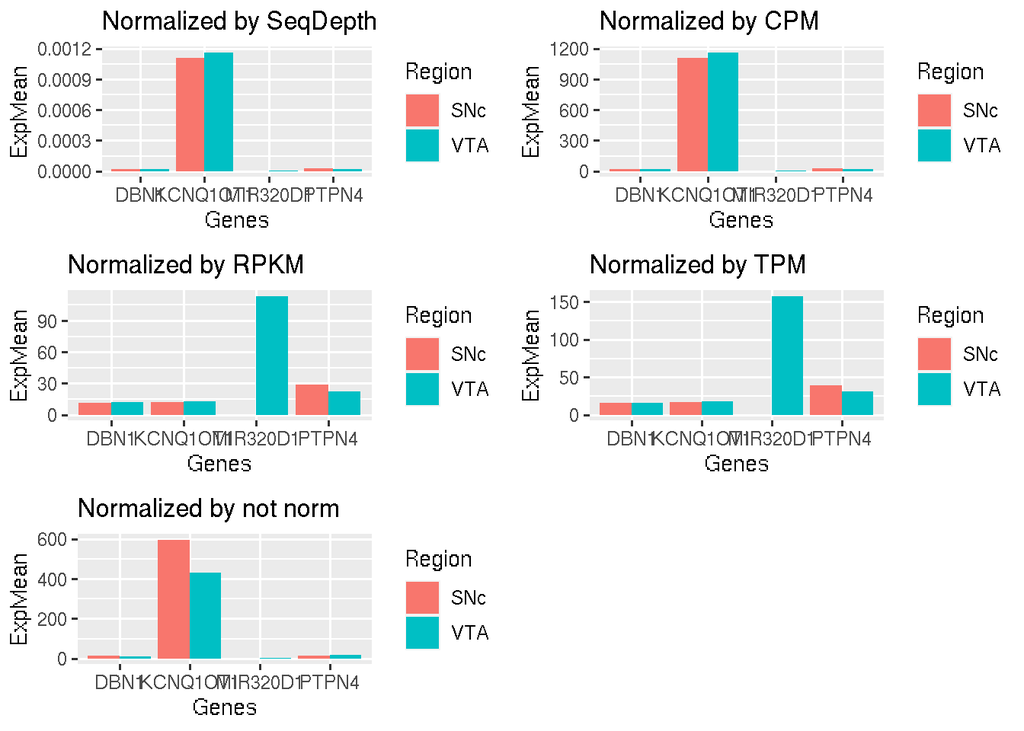

```r
set.seed(0)
genesrandom<-sample(`trnsc_analyze_n&cpm&rpkm&tpm`, 2)

trnsc_analyze<-c("MIR320D1", "KCNQ1OT1", genesrandom)

MeanPlot<- function(RealMat, method, trnsc){
  RealMat <- as.data.frame(RealMat)
  RealMat$Genes<- rownames(RealMat)
  RealMat_l <- tidyr::pivot_longer(RealMat, starts_with("PD"), names_to = "Samples")
  names(RealMat_l)[3] <- "Exp"
  RealMat_l <- mutate(RealMat_l, Region = str_split_fixed(Samples, "_", 3)[,3])
  MeanRealMat<- group_by(RealMat_l, Genes, Region) %>% summarise(ExpMean = mean(Exp))


# Plot
ggplot2::ggplot(filter(MeanRealMat, Genes %in% trnsc), aes(x = Genes, y = ExpMean)) +
  geom_col(aes(fill = Region), position = "dodge") +
  ggtitle(paste0("Normalized by ", method))
}

p3<-MeanPlot(vRealMatrix_n, "SeqDepth", trnsc_analyze)
p4<-MeanPlot(vRealMatrix_cpm, "CPM", trnsc_analyze)
p5<-MeanPlot(vRealMatrix_rpkm, "RPKM", trnsc_analyze)
p6<-MeanPlot(vRealMatrix_tpm, "TPM", trnsc_analyze)
p7<-MeanPlot(RealMatrix, "not norm", trnsc_analyze)

grid.arrange(p3, p4, p5, p6, p7, nrow = 3, ncol = 2)
```

```r
# Notar las diferencias en las escalas de los ejes y donde caen los valores.
```

**Para pensar…**  
A partir de estos graficos, que podemos decir en cuenta a como afecta la normalizacion a las diferencias en la media de expresion?  
Tene en cuenta no solo las diferencias que se pueden ver entre SNc y VTA sino tmb las direncias entre los genes en las distintas normalizciones. Podes seleccionar a mano otro set de genes y fijarte que otras cosas podes encontrar

### Veamos que pasa ahora si hacemos un test estadistico para comparar las muestras

**Importante**: Se hace un test por gen, porque el gen es la variable respuesta.  
Si suponemos que las read counts siguen una distribucion normal, podemos hacer un t-test.  
(Otro dia vemos graficos diagnosticos para ver si una variable sigue algun tipo de distribucion en particular)  
Hagamos un Student t-test:

```r
#Usameos primero los datos de prueba
GroupA<- c("samp1.A", "samp2.A", "samp3.A")
GroupB<- c("samp1.B", "samp2.B", "samp3.B")
# Si no normalizo
ttest_out <- apply(ExpMatriz, 1, function(dat) {
  t.test(x = dat[GroupA], y = dat[GroupB], alternative = "two.sided")$p.value})
# Si normalizo
ttest_out_n <- apply(ExpMatriz_n, 1, function(dat) {
  t.test(x = dat[GroupA], y = dat[GroupB], alternative = "two.sided")$p.value})

# Genero ahora un df de los p values obtenidos
ttest_ExpMatriz<-data.frame(ttest_out, ttest_out_n)
head(ttest_ExpMatriz)
```

```
##      ttest_out ttest_out_n
## gen1 0.9257986  0.87136670
## gen2 1.0000000  0.60681567
## gen3 0.1768661  0.01072418
## gen4 0.2164925  0.03700095
```

```r
# Considereando como significativo los tets con un p.valor < 0.05, vemos que los genes 3 y 4 pasan de no estar diferencialmente expresados entre los grupos A y B, a estarlo.

# Hagamos lo mismo ahora pero con la matriz de expresion real:
# Nos contruimos una funcion para no escribir tanto texto:
ttest_pval <- function(ExpMat, condA, condB) {
  apply(ExpMat, 1, function(dat) {t.test(x = dat[condA], y = dat[condB], alternative = "two.sided")$p.value})
}

# Nuestros grupos son:
SNc<-grep("SNc", colnames(RealMatrix), value = T)
VTA<-grep("VTA", colnames(RealMatrix), value = T)

ttest_RM_n <- ttest_pval(vRealMatrix_n[`trnsc_analyze_n&cpm&rpkm&tpm`, ], SNc, VTA)
ttest_RM_cpm <- ttest_pval(vRealMatrix_cpm[`trnsc_analyze_n&cpm&rpkm&tpm`,], SNc, VTA)
ttest_RM_rpkm <- ttest_pval(vRealMatrix_rpkm[`trnsc_analyze_n&cpm&rpkm&tpm`,], SNc, VTA)
ttest_RM_tpm <- ttest_pval(vRealMatrix_tpm[`trnsc_analyze_n&cpm&rpkm&tpm`,], SNc, VTA)

# Y nuestro df con los pvalores de cada normalizacion
# Lo que sigue me va a dar error porque al final , por el tema de la equivalencias, tengo un numero distinto de genes evaluados, por ende, la matriz tmb es distinta
# ttest_RealMatriz<-data.frame(ttest_RM_n, ttest_RM_cpm, ttest_RM_rpkm, ttest_RM_tpm)
# Asi que lo hago asi:
ttest_RealMatriz<-data.frame(ttest_RM_n, ttest_RM_cpm, ttest_RM_rpkm, ttest_RM_tpm)
head(ttest_RealMatriz)
```

```
##        ttest_RM_n ttest_RM_cpm ttest_RM_rpkm ttest_RM_tpm
## LEF1   0.37390097   0.37390097    0.37390097   0.37390097
## FOXJ2  0.15929503   0.15929503    0.15929503   0.15576075
## ZNF654 0.08965885   0.08965885    0.08965885   0.08827349
## ZMYM2  0.43155560   0.43155560    0.43155560   0.42645252
## DCAF6  0.29675842   0.29675842    0.29675842   0.29567458
## PDP1   0.31905524   0.31905524    0.31905524   0.31544842
```